Problem Solving Hamza Snoussi 20-Aout-2021

# Overview : The Queen’s Attack : HackerRank

I chose this particular problem because i personally love chess and because it is a quite challenging problem, in fact only 64% of those who tried this problem actually succeed at solving it.

Here’s the problem description

[figure not shown]

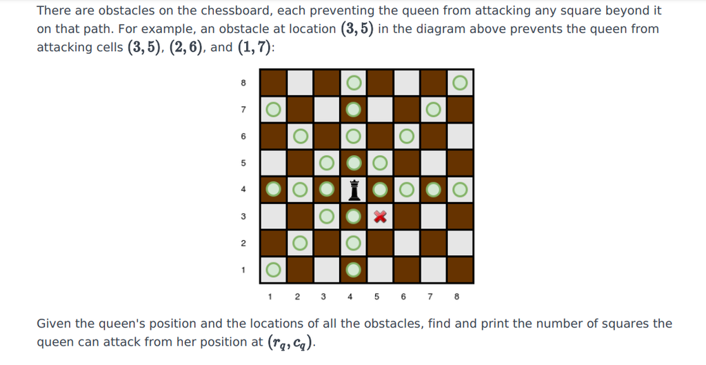

# Solution

in my first attempt to solve this exciting problem, i literally took the queen and brute-force moves calculation and checking for obstacle in every square in the queen eight directions, for a large input, a very bad case scenario is when there is no obstacle in one or many certain directions, the algorithm will check every square in every direction anyway.

So in order to have a better solution decided to split the problem in two parts : - calculate the edges of the given board relatively to the queen position. - identify the closest obstacles to the queen and calculate the total number of legal moves.

## Part One

having the edges of the chessboard for each case before considering the obstacles given a position of the queen and a dimension of the board will be a good step in having an optimal solution. this first function will calculate the steps a queen can make when there is no obstacle and takes dimension of the board n, row position of the queen r_q and column position c_q as input and returns the total steps of the queen, number of steps in each direction and a table containing all the edges , if you want to access only the table or the number of move in a certain direction, you can do that by doing

```r
QueenMoves(8,3,2)$table_of_edges
```

```
                Row Column
up_edge           8      2
down_edge         1      2
right_edge        3      8
left_edge         3      1
right_up_edge     1      4
right_down_edge   8      7
left_up_edge      2      1
left_down_edge    4      1
```

```r
QueenMoves(8,3,2)$up_steps
```

```
[1] 5
```

this is the first part of the solution and it has a time complexity of O(1) because it only uses only arithmetic expressions and optimized min/max R built-in functions. the function is tested on different cases and as you can see below it took just ~ 0.02 seconds to output the edges and the number of steps in each direction of a 1M*1M board for a random given position

```r
# select random coordinates and setting n to 1M
c_q = sample(1:1000000,1)
r_q = sample(1:1000000,1)
n = 1000000
# defining start time
startTime = Sys.time()
# executing the function
QueenMoves(n,r_q,c_q)
```

```
$up_steps
[1] 304327

$down_steps
[1] 695672

$right_steps
[1] 959908

$left_steps
[1] 40091

$left_up_steps
[1] 40091

$left_down_steps
[1] 40091

$right_up_steps
[1] 695672

$right_down_steps
[1] 304327

$total_steps
[1] 3080179

$table_of_edges
                    Row  Column
up_edge         1000000   40092
down_edge             1   40092
right_edge       695673 1000000
left_edge        695673       1
right_up_edge         1  735764
right_down_edge 1000000  344419
left_up_edge     655582       1
left_down_edge   735764       1
```

```r
# calculating diffrence time
endTime = Sys.time()
endTime - startTime
```

```
Time difference of 0.01600099 secs
```

# Part Two

in this part of the solution the first step i took is to define the real obstacles which are the obstacles excluding unnecessary obstacles meaning obstacles that are not in the queen’s trajectory this step is made easy because we will use the calculated then splitting the result according each direction (right_real_obstacles,left_real_obstacles, …) the next step is identify the closest obstacle by finding the minimum or maximum (according to whether the queen is going up or down, left or right…) then finally sum all the differences between the closest obstacles and the queen position for each direction

since we will be iterating through the all the obstacles only once (to find the relevant ones) this second part of the solution has an O(k) time complexity where k is the number of obstacles.

```r
# start time
startTime = Sys.time()
# function execution (Object obstacle is downloaded from the problem page)
queensAttack(n = 100000 , k = 100000  , r_q = 4697, c_q = 4728 , obstacles)
```

```
[1] 30544
```

```r
endTime = Sys.time()
```

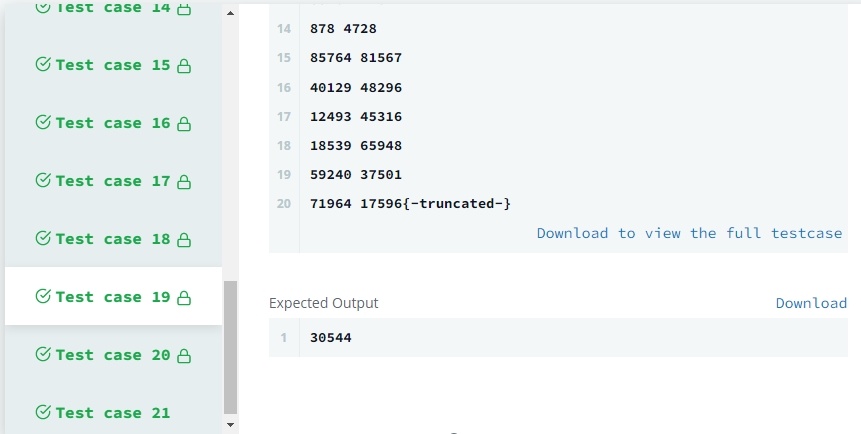

HackerRank : Queen’s Attack 19th test case

```r
# calculating the time difference

endTime - startTime
```

```
Time difference of 1.563543 secs
```